# Differential Expression Analysis

Loss of brain insulin production in female mice (GSE305902)

```r
# Required libraries

library(GEOquery)
library(DESeq2)
library(ggplot2)
library(ggrepel)
library(pheatmap)
library(AnnotationDbi)
library(org.Mm.eg.db)
library(clusterProfiler)
library(ReactomePA)
library(stringr)
library(msigdbr)
library(gplots)
library(dplyr)
library (enrichplot)
```

## Data and Metadata Retrieval

We first connect to the NCBI Gene Expression Omnibus (GEO) repository to retrieve both the phenotypic metadata and the raw count matrix for GSE305902.

```r
#Phenotypical matrix extraction
geo <- GEOquery::getGEO(GEO = "GSE305902", GSEMatrix = TRUE)
colData <- Biobase::pData(geo[[1]])

#Raw counts extraction
GEOquery::getGEOSuppFiles(GEO = "GSE305902")
```

## Sample Metadata Cleaning

Here, we clean the raw metadata retrieved from GEO. We isolate the vital sample identifiers, define the main biological condition (Genotype: Wild-Type vs. $Ins2^{-/-}$ Knockout), and generate unique sample IDs (Snumber) derived directly from the original submission titles.

```r
#Cleaning colData

metadata_clean <- colData[, c("geo_accession", "title")]

metadata_clean$Genotype <- ifelse(grepl("WT", metadata_clean$title), "WT", "KO")
metadata_clean$Genotype <- as.factor(metadata_clean$Genotype)

sample_numbers <- gsub("WT_|KO_", "", metadata_clean$title)

metadata_clean$Snumber <- paste0("Snumber", sample_numbers)
rownames(metadata_clean) <- metadata_clean$Snumber
```

## Count Matrix Loading and Alignment

We load the raw transcriptomic count matrix. To fulfill the requirements of DESeq2, we reorder the matrix columns to match the exact order of our metadata rows. We then round the counts to the nearest integer to eliminate any decimals.

```r
#Raw counts
counts_path <- "GSE305902/GSE305902_jjohnson_hippocampus_counts.txt.gz"
counts <- read.delim(counts_path, row.names = 1, header = TRUE)


#Re-ordering counts: colnames(counts) must be in the same identical order of rownames(metadata_clean) for DESeq2
counts <- counts[, rownames(metadata_clean)]

#Decimal rounding
counts <- round(counts)
all(colnames(counts) == rownames(metadata_clean))
```

```
## [1] TRUE
```

## Creation of the DESeq2 Object

We initialize the differential expression analysis by constructing a DESeqDataSet object. We supply the aligned count matrix and metadata, setting Genotype as the design formula factor since it represents the primary biological variable testing the effect of brain insulin loss.

```r
#Creating DESeqDataSet object

dds <- DESeqDataSetFromMatrix(
  countData = counts,
  colData = metadata_clean,
  design = ~ Genotype
)
```

## Filtering Low Expressed Genes

We perform a pre-filtering step to remove genes with low coverage (rowSums(counts(dds)) > 1) across all samples. This process removes uninformative features with near-zero counts, maximizing statistical power during the independent filtering phase.

```r
keep <- rowSums(counts(dds)) > 1
dds <- dds[keep, ]
```

## Running DESeq2 Differential Expression Pipeline

With the dataset filtered and properly aligned, we execute the main DESeq2 differential expression analysis pipeline. This single function automates library size normalization, gene-wise dispersion estimation, and fits the negative binomial generalized linear model to test for expression differences between WT and KO samples.

```r
#Run DESeq2 pipeline to obtain dds object containing: size factors, dispersion estimates, linear model fits and hypothesis testing

dds <- DESeq(dds)
```

## Principal Component Analysis (PCA)

To visualize the overall similarity between our transcriptomic samples, we first apply a Variance Stabilizing Transformation (vst) to normalize the count data. We then generate a PCA plot to assess whether the biological samples cluster together based on their Genotype (WT vs KO).

### Initial PCA: 23 samples

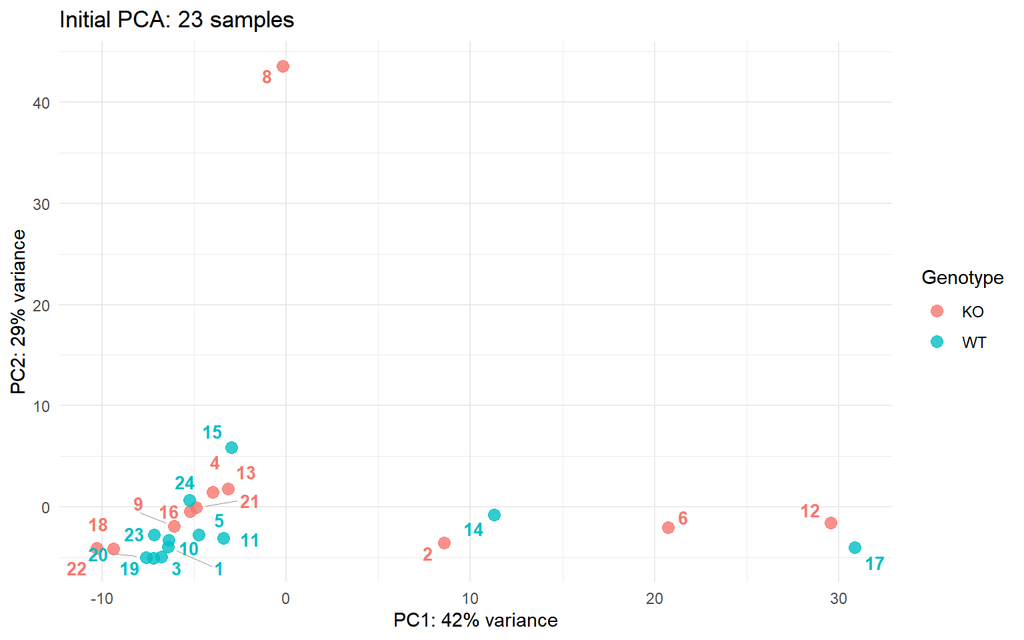

```r
#Data transformation for PCA: making variance constant for all genes
vsd <- vst(dds, blind = FALSE)

pcaData <- plotPCA(vsd, intgroup = c("Genotype", "title", "Snumber"), returnData = TRUE)
percentVar <- round(100 * attr(pcaData, "percentVar"))

#Grabbing sample number from labels
pcaData$JustNumber <- gsub("[^0-9]", "", pcaData$title)

ggplot(pcaData, aes(PC1, PC2, color = Genotype, label = JustNumber)) +
  geom_point(size = 3, alpha = 0.8) +
  geom_text_repel(
    size = 3.5,
    fontface = "bold",
    show.legend = FALSE,
    max.overlaps = Inf,
    box.padding = 0.3,
    point.padding = 0.3,
    segment.color = "grey60",
    segment.size = 0.3
  ) +
  xlab(paste0("PC1: ", percentVar[1], "% variance")) +
  ylab(paste0("PC2: ", percentVar[2], "% variance")) +
  theme_minimal() +
  ggtitle("Initial PCA: 23 samples")
```

### PCA 2: sample 8 removal

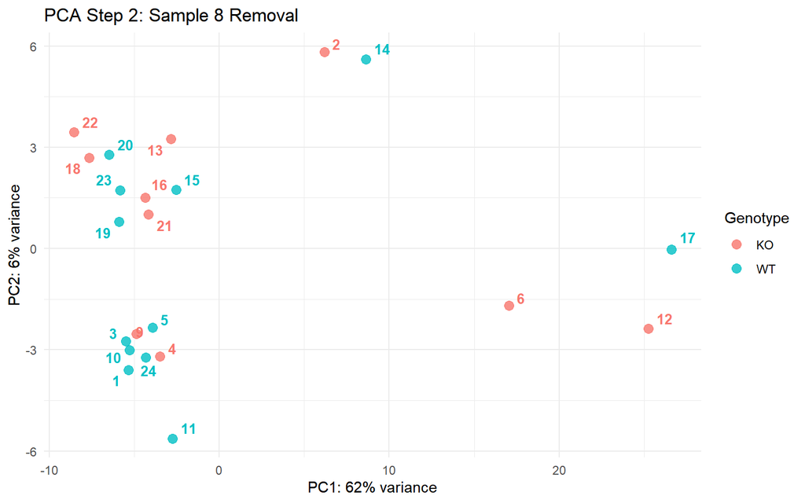

```r
dds_no8 <- dds[, colnames(dds) != "Snumber8"]
dds_no8$Genotype <- droplevels(dds_no8$Genotype)

vsd_no8 <- vst(dds_no8, blind = FALSE)
pcaData_no8 <- plotPCA(vsd_no8, intgroup = c("Genotype", "title", "Snumber"), returnData = TRUE)
percentVar_no8 <- round(100 * attr(pcaData_no8, "percentVar"))

pcaData_no8$JustNumber <- gsub("[^0-9]", "", pcaData_no8$title)

ggplot(pcaData_no8, aes(PC1, PC2, color = Genotype, label = JustNumber)) +
  geom_point(size = 3, alpha = 0.8) +
  geom_text_repel(
    size = 3.5,
    fontface = "bold",
    show.legend = FALSE,
    max.overlaps = Inf,
    box.padding = 0.3,
    point.padding = 0.3,
    segment.color = "grey60",
    segment.size = 0.3
  ) +
  xlab(paste0("PC1: ", percentVar_no8[1], "% variance")) +
  ylab(paste0("PC2: ", percentVar_no8[2], "% variance")) +
  theme_minimal() +
  ggtitle("PCA Step 2: Sample 8 Removal")
```

### PCA 3: samples 8, 6, 12, 17 removal

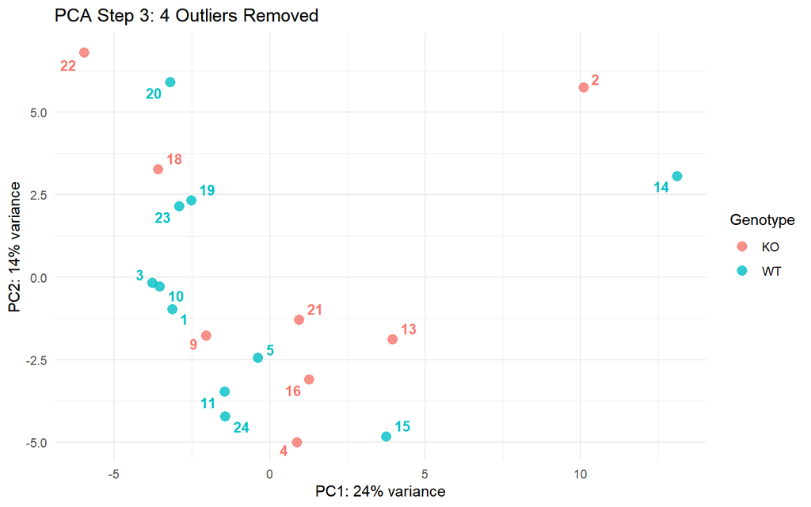

```r
outliers <- c("Snumber8", "Snumber6", "Snumber12", "Snumber17")
dds_clean <- dds[, !(colnames(dds) %in% outliers)]
dds_clean$Genotype <- droplevels(dds_clean$Genotype)

vsd_clean <- vst(dds_clean, blind = FALSE)
pcaData_clean <- plotPCA(vsd_clean, intgroup = c("Genotype", "title", "Snumber"), returnData = TRUE)
percentVar_clean <- round(100 * attr(pcaData_clean, "percentVar"))

pcaData_clean$JustNumber <- gsub("[^0-9]", "", pcaData_clean$title)

ggplot(pcaData_clean, aes(PC1, PC2, color = Genotype, label = JustNumber)) +
  geom_point(size = 3, alpha = 0.8) +
  geom_text_repel(
    size = 3.5,
    fontface = "bold",
    show.legend = FALSE,
    max.overlaps = Inf,
    box.padding = 0.3,
    point.padding = 0.3,
    segment.color = "grey60",
    segment.size = 0.3
  ) +
  xlab(paste0("PC1: ", percentVar_clean[1], "% variance")) +
  ylab(paste0("PC2: ", percentVar_clean[2], "% variance")) +
  theme_minimal() +
  ggtitle("PCA Step 3: 4 Outliers Removed")
```

## Sample-to-Sample Distances Heatmaps

To further investigate the similarities and differences between samples, we compute a Euclidean distance matrix between all pairs of samples using the VST-transformed data. We then visualize this matrix as a heatmap, adding an annotation bar to verify how closely the biological replicates cluster according to their Genotype.

### Heatmap 23 samples

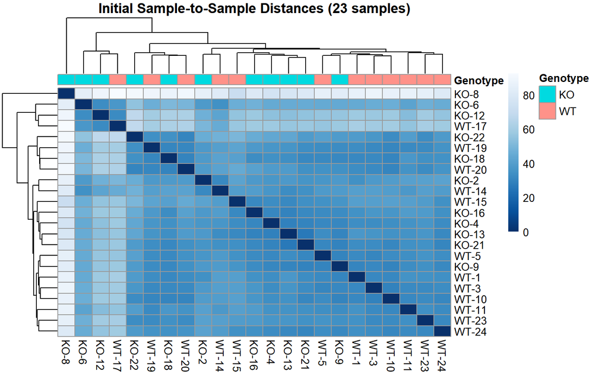

```r
#Calculating Euclidean distances between samples considering gene expression
sampleDists <- dist(t(assay(vsd)))
sampleDistMatrix <- as.matrix(sampleDists)

just_numbers <- gsub("[^0-9]", "", vsd$title)
sample_names <- paste(vsd$Genotype, just_numbers, sep="-")

rownames(sampleDistMatrix) <- sample_names
colnames(sampleDistMatrix) <- sample_names

annotation_col <- data.frame(Genotype = vsd$Genotype)
rownames(annotation_col) <- sample_names

colors <- colorRampPalette(rev(RColorBrewer::brewer.pal(9, "Blues")))(255)

pheatmap(sampleDistMatrix,
         clustering_distance_rows = sampleDists,
         clustering_distance_cols = sampleDists,
         col = colors,
         annotation_col = annotation_col,
         main = "Initial Sample-to-Sample Distances (23 samples)")
```

### Heatmap cleaned dataset (4 outliers removed)

We recalculate the euclidean distance matrix using vsd_clean.

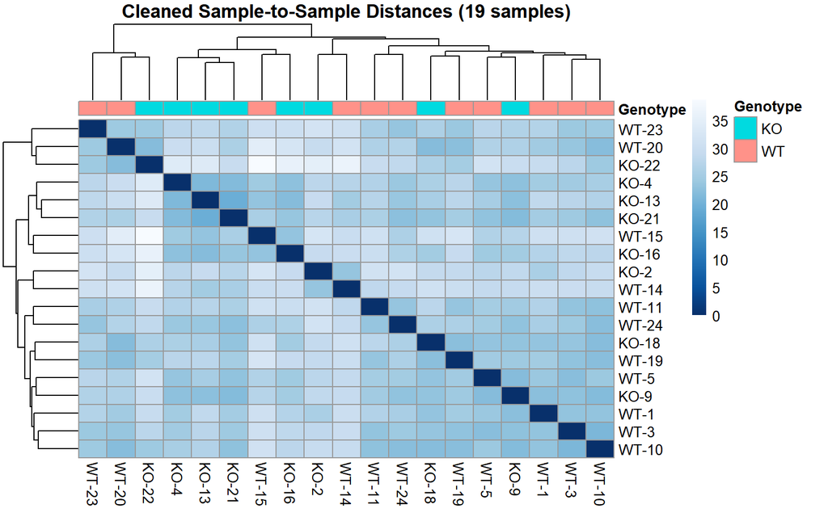

```r
sampleDists_clean <- dist(t(assay(vsd_clean)))
sampleDistMatrix_clean <- as.matrix(sampleDists_clean)

just_numbers_clean <- gsub("[^0-9]", "", vsd_clean$title)
sample_names_clean <- paste(vsd_clean$Genotype, just_numbers_clean, sep="-")

rownames(sampleDistMatrix_clean) <- sample_names_clean
colnames(sampleDistMatrix_clean) <- sample_names_clean

annotation_col_clean <- data.frame(Genotype = vsd_clean$Genotype)
rownames(annotation_col_clean) <- sample_names_clean

#Cleaned heatmap
pheatmap(sampleDistMatrix_clean,
         clustering_distance_rows = sampleDists_clean,
         clustering_distance_cols = sampleDists_clean,
         col = colors,
         annotation_col = annotation_col_clean,
         main = "Cleaned Sample-to-Sample Distances (19 samples)")
```

### Heatmap 22 samples (Sample 8 removed)

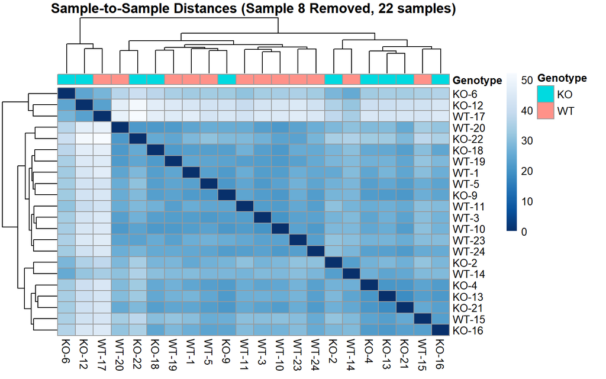

```r
sampleDists_no8 <- dist(t(assay(vsd_no8)))
sampleDistMatrix_no8 <- as.matrix(sampleDists_no8)

just_numbers_no8 <- gsub("[^0-9]", "", vsd_no8$title)
sample_names_no8 <- paste(vsd_no8$Genotype, just_numbers_no8, sep="-")

rownames(sampleDistMatrix_no8) <- sample_names_no8
colnames(sampleDistMatrix_no8) <- sample_names_no8

annotation_col_no8 <- data.frame(Genotype = vsd_no8$Genotype)
rownames(annotation_col_no8) <- sample_names_no8

pheatmap(sampleDistMatrix_no8,
         clustering_distance_rows = sampleDists_no8,
         clustering_distance_cols = sampleDists_no8,
         col = colors,
         annotation_col = annotation_col_no8,
         main = "Sample-to-Sample Distances (Sample 8 Removed, 22 samples)")
```

## Differential Expression Results Extraction

We extract the results of the differential expression analysis comparing our target condition (Knockout) against the reference control group (Wild-Type).

By excluding the 4 outlier samples identified through the PCA, the statistical power of the analysis improved substantially. The reduction of intra-group non-biological variance successfully uncovered fifteen additional differentially expressed genes (moving from 4 to 19 total significant genes with padj less than 0.05), which were previously masked by background noise.

The removal of the outliers allowed DESeq2’s independent filtering algorithm to optimize the low-count filtering threshold, shifting from a mean count < 0 to a mean count < 4. By filtering out 33% of uninformative, lowly expressed genes, the multiple testing burden was drastically reduced via the Benjamini-Hochberg correction, allowing biologically relevant genes—such as our positive control **Ccnd1**—to achieve statistical significance (padj = 8.34e-44).

```r
## Confronting Before and After Differentially Expressed Genes

#23 samples
dds <- DESeq(dds)

res_dirty <- results(dds, contrast = c("Genotype", "KO", "WT"), alpha = 0.05)
summary(res_dirty)
```

```
##
## out of 27360 with nonzero total read count
## adjusted p-value < 0.05
## LFC > 0 (up)       : 3, 0.011%
## LFC < 0 (down)     : 1, 0.0037%
## outliers [1]       : 0, 0%
## low counts [2]     : 8, 0.029%
## (mean count < 0)
## [1] see 'cooksCutoff' argument of ?results
## [2] see 'independentFiltering' argument of ?results
```

```r
#Cleaned up dataset (removal of 4 outliers)
#Filter for low expressed genes (>1)

keep_clean <- rowSums(counts(dds_clean)) > 1
dds_clean <- dds_clean[keep_clean, ]

dds_clean <- DESeq(dds_clean)

res_clean <- results(dds_clean, contrast = c("Genotype", "KO", "WT"), alpha = 0.05)

summary(res_clean)
```

```
##
## out of 26730 with nonzero total read count
## adjusted p-value < 0.05
## LFC > 0 (up)       : 12, 0.045%
## LFC < 0 (down)     : 7, 0.026%
## outliers [1]       : 0, 0%
## low counts [2]     : 8814, 33%
## (mean count < 4)
## [1] see 'cooksCutoff' argument of ?results
## [2] see 'independentFiltering' argument of ?results
```

## Checking CCnd1 behaviour

```r
res_clean$symbol <- mapIds(
  org.Mm.eg.db,
  keys = rownames(res_clean),
  column = "SYMBOL",
  keytype = "ENSEMBL",
  multiVals = "first"
)

ccnd1_row <- which(res_clean$symbol == "Ccnd1")

if(length(ccnd1_row) > 0) {
  print(res_clean[ccnd1_row, ])
} else {
  cat("No Ccnd1 gene.\n")
}
```

```
## log2 fold change (MLE): Genotype KO vs WT
## Wald test p-value: Genotype KO vs WT
## DataFrame with 1 row and 7 columns
##                     baseMean log2FoldChange     lfcSE      stat      pvalue
##                    <numeric>      <numeric> <numeric> <numeric>   <numeric>
## ENSMUSG00000070348   815.827        -1.1603 0.0796612  -14.5655 4.65548e-48
##                           padj      symbol
##                      <numeric> <character>
## ENSMUSG00000070348 8.34263e-44       Ccnd1
```

## MA-Plot Visualization

We generate an MA-plot to visualize the relationship between the log2 fold changes and the mean of normalized counts for all tested genes.

### MA-Plot on initial Dataset (23 samples)

This plot illustrates the expression profile before outliers removal, where statistical significance is largely suppressed by background noise.

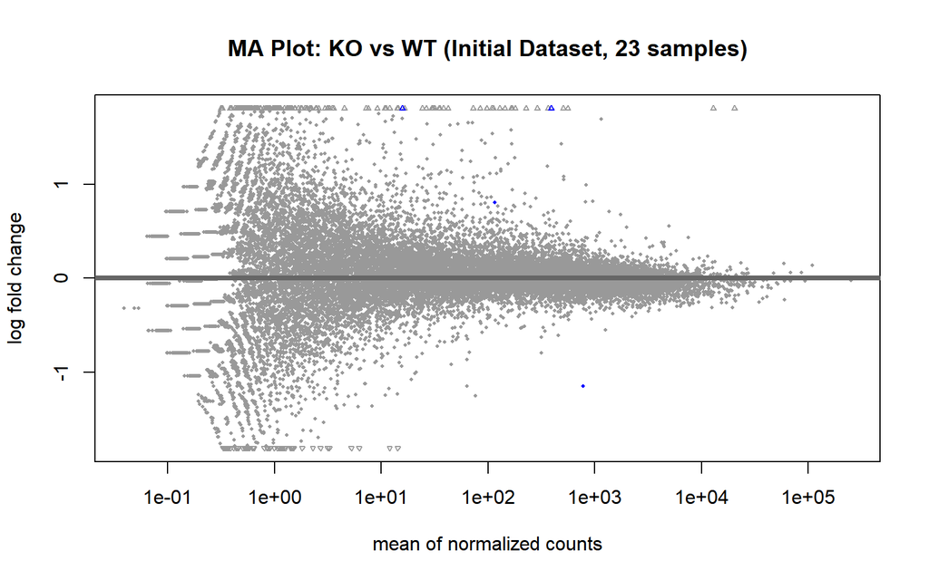

```r
plotMA(res_dirty, main = "MA Plot: KO vs WT (Initial Dataset, 23 samples)")
```

### MA-Plot on cleaned Dataset (4 outliers removed)

This plot illustrates the refined expression profile after excluding all four identified outliers.

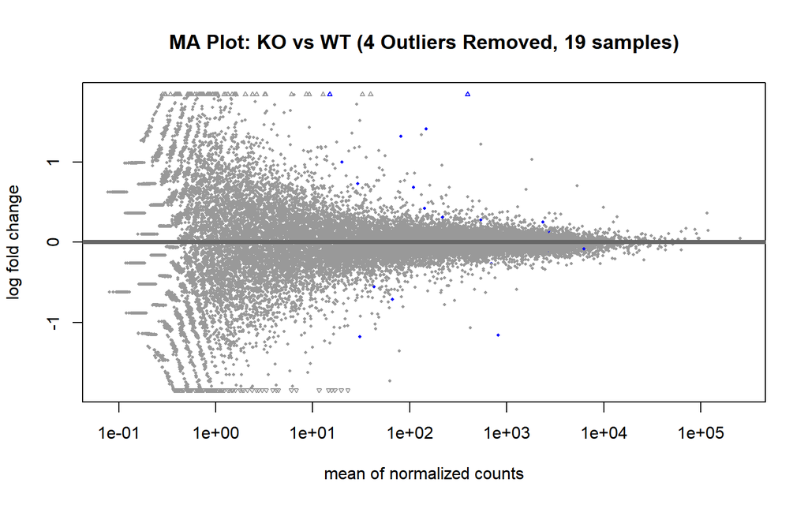

```r
plotMA(res_clean, main = "MA Plot: KO vs WT (4 Outliers Removed, 19 samples)")
```

### MA-Plot with Ccnd1 Highlighted

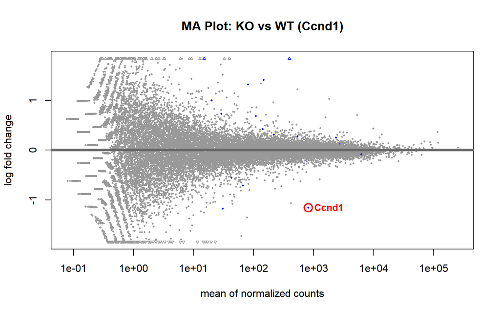

```r
plotMA(res_clean, main = "MA Plot: KO vs WT (Ccnd1)")

ccnd1_id <- "ENSMUSG00000070348"
ccnd1_data <- res_clean[ccnd1_id, ]

points(
  x = ccnd1_data$baseMean,
  y = ccnd1_data$log2FoldChange,
  col = "red",
  lwd = 2,
  cex = 1.8,
  pch = 1
)

text(
  x = ccnd1_data$baseMean,
  y = ccnd1_data$log2FoldChange,
  labels = "Ccnd1",
  pos = 4,
  col = "red",
  font = 2,
  cex = 0.9
)
```

## Top 50 Differently Expressed Genes Heatmaps

To visualize the expression patterns of the top 50 most differentially expressed genes, we extract their profiles using both the VST (Variance Stabilizing Transformation) and RLOG (Regularized Logarithm) transformation matrices, applying row-wise scaling to emphasize relative expression changes across samples.

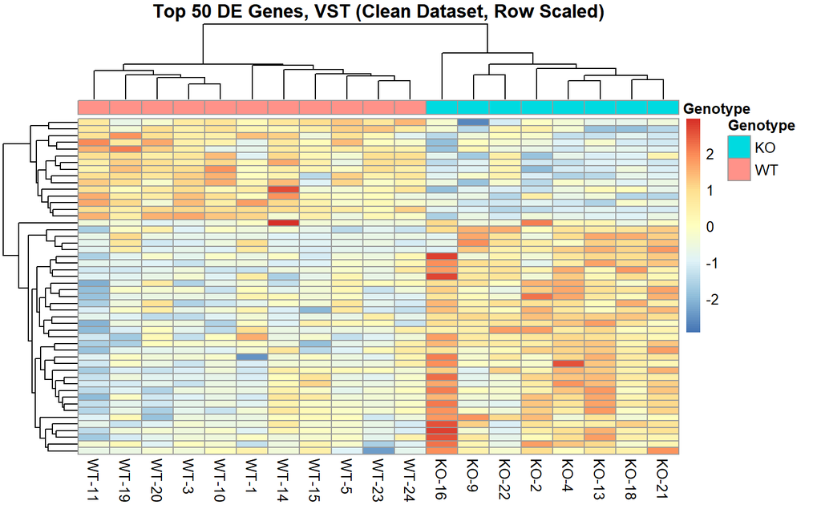

```r
#Running rlog on cleaned dataset
rld_clean <- rlog(dds_clean, blind = FALSE)

#Extracting top 50 genes sorted by their adjusted p-value from clean results
top50_genes <- head(order(res_clean$padj), 50)

just_numbers_clean <- gsub("[^0-9]", "", vsd_clean$title)
sample_names_clean <- paste(vsd_clean$Genotype, just_numbers_clean, sep="-")

annotation_col_clean <- data.frame(Genotype = vsd_clean$Genotype)
rownames(annotation_col_clean) <- sample_names_clean

# VST MATRIX
vsd_clean <- vst(dds_clean, blind = FALSE)

vst_matrix <- assay(vsd_clean)[top50_genes, ]
colnames(vst_matrix) <- sample_names_clean

pheatmap(vst_matrix,
         cluster_rows = TRUE, #clustering genes with similar gene expression
         show_rownames = FALSE,
         cluster_cols = TRUE,
         annotation_col = annotation_col_clean,
         scale = "row", #applies Z-score on rows
         main = "Top 50 DE Genes, VST (Clean Dataset, Row Scaled)")
```

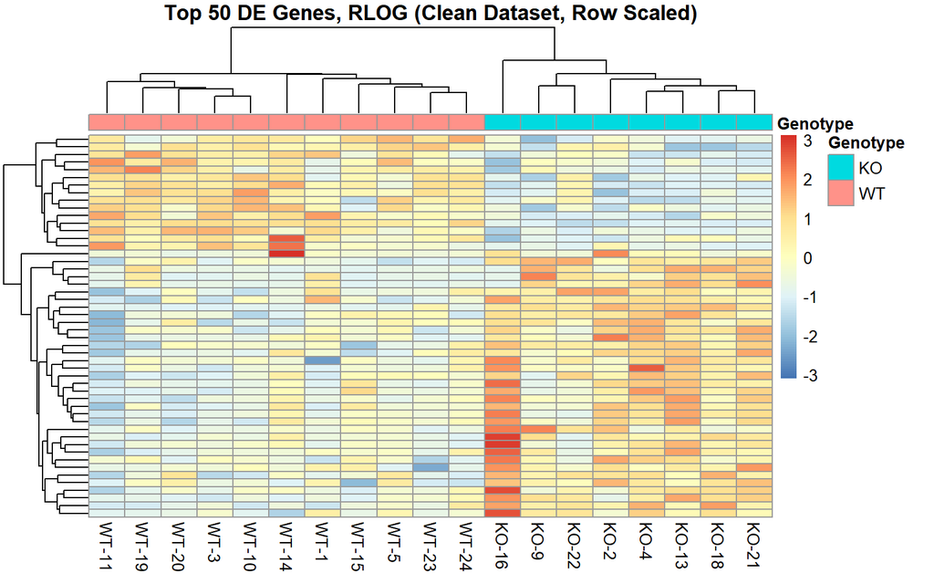

```r
# RLOG MATRIX
rlog_matrix <- assay(rld_clean)[top50_genes, ]
colnames(rlog_matrix) <- sample_names_clean

pheatmap(rlog_matrix,
         cluster_rows = TRUE,
         show_rownames = FALSE,
         cluster_cols = TRUE,
         annotation_col = annotation_col_clean,
         scale = "row",
         main = "Top 50 DE Genes, RLOG (Clean Dataset, Row Scaled)")
```

## Volcano Plot: statistical significance vs magnitude of change for the 19 DEGs

To demonstrate the statistical dominance of the primary control, we plot the 19 significant genes by mapping their magnitude of change (Log2 Fold Change) on the X-axis against their $-log_{10}(padj)$ on the Y-axis. This visualization highlights why **Ccnd1** is the most robust and reliable biological discovery.

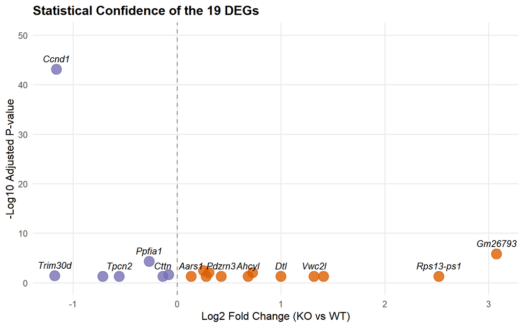

```r
#Isolating 19 significant genes
degs_19 <- as.data.frame(res_clean[which(res_clean$padj < 0.05), ])

#Adding gene symbol
degs_19$Gene_Symbol <- mapIds(org.Mm.eg.db, keys = rownames(degs_19), column = "SYMBOL", keytype = "ENSEMBL", multiVals = "first")
degs_19$Gene_Symbol <- ifelse(is.na(degs_19$Gene_Symbol), rownames(degs_19), degs_19$Gene_Symbol)

degs_19$Gene_Symbol[rownames(degs_19) == "ENSMUSG00000096999"] <- "Gm26793"

#-log10 of padj for vertical scaling
degs_19$log_sig <- -log10(degs_19$padj)

ggplot(degs_19, aes(x = log2FoldChange, y = log_sig)) +
  geom_vline(xintercept = 0, linetype = "dashed", color = "grey60") +
  geom_point(aes(color = log2FoldChange > 0), size = 5, alpha = 0.8) +
  geom_text(aes(label = Gene_Symbol),
            vjust = -1,
            fontface = "italic",
            size = 3.5,
            color = "black",
            check_overlap = TRUE) +
  scale_color_manual(values = c("TRUE" = "#d95f02", "FALSE" = "#7570b3"), guide = "none") +
  labs(
    title = "Statistical Confidence of the 19 DEGs",
    x = "Log2 Fold Change (KO vs WT)",
    y = "-Log10 Adjusted P-value"
  ) +
  ylim(0, 50) +
  theme_minimal(base_size = 12) +
  theme(
    plot.title = element_text(face = "bold", size = 14),
    panel.grid.minor = element_blank()
  )
```

#UP Regulated and DOWN Regulated DEGs

```r
#Upregulated
sum(degs_19$log2FoldChange > 0)
```

```
## [1] 12
```

```r
#Downregulated
sum(degs_19$log2FoldChange < 0)
```

```
## [1] 7
```

## Gene Ontology (GO) Enrichment Analysis

We map our Ensembl gene IDs to standard Gene Symbols and Entrez IDs using the mouse annotation database (org.Mm.eg.db). Then, we isolate the significantly Up-regulated and Down-regulated genes ($padj < 0.05$) into a stratified list to perform a comparative Over-Representation Analysis (ORA) for Biological Processes (BP) and Molecular Functions (MF) using clusterProfiler.

We should note that the functional enrichment analysis was initiated using our core set of 19 significantly differential genes (12 UP-regulated and 7 DOWN-regulated). During the bioinformatic ID conversion from Ensembl identifiers to standard Gene Symbols, the org.Mm.eg.db annotation package could not recover an official mapping for two features (1 UP and 1 DOWN). Consequently, the Over-Representation Analysis (ORA) was executed on an effective input list of 11 UP and 6 DOWN-regulated genes.

In Phase 1, a rigorous false discovery rate control was enforced using the Benjamini-Hochberg (BH) adjustment method ($FDR < 0.05$). As expected with an input size this restrictive, the statistical power was severely compromised; only a minimal fraction of terms reached significance within the DOWN-regulated cluster, while no terms were significantly enriched for the UP-regulated group. To circumvent this structural mathematical constraint and capture underlying biological signals, we implemented a Phase 2 exploratory approach by disabling the multi-test correction (pAdjustMethod = “none”) to evaluate nominal p-values. This step serves a hypothesis-generating purpose to reveal trends that would otherwise be entirely masked by the FDR penalty. It must be noted that this exploratory framework inherently carries a higher risk of false positives.

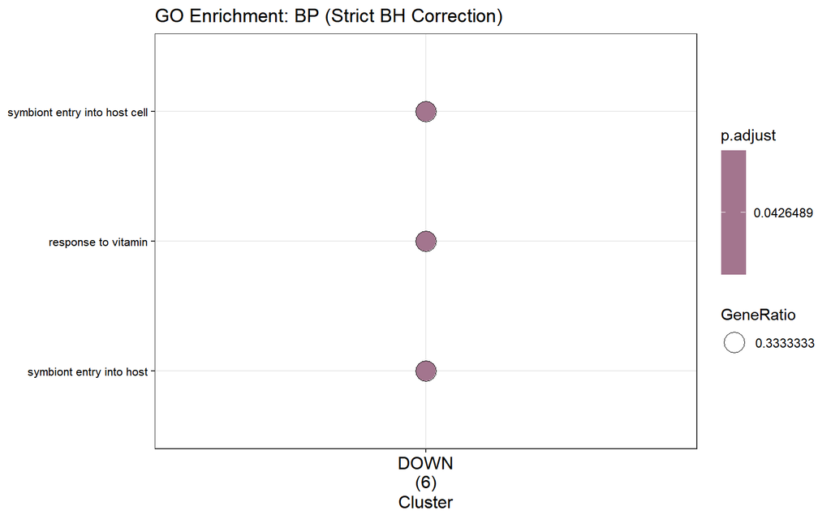

```r
res_df <- as.data.frame(res_clean)

#Mapping IDs
res_df$symbol <- mapIds(
  org.Mm.eg.db,
  keys = rownames(res_df),
  column = "SYMBOL",
  keytype = "ENSEMBL",
  multiVals = "first"
)

res_df$entrez <- mapIds(
  org.Mm.eg.db,
  keys = rownames(res_df),
  column = "ENTREZID",
  keytype = "ENSEMBL",
  multiVals = "first"
)

#Definition of Universe and Gene Lists
gene_universe <- res_df$symbol[!is.na(res_df$padj)]
entrez_universe <- res_df$entrez[!is.na(res_df$padj)]

up_genes_strict <- res_df$symbol[res_df$log2FoldChange > 0 & res_df$padj < 0.05 & !is.na(res_df$padj)]
down_genes_strict <- res_df$symbol[res_df$log2FoldChange < 0 & res_df$padj < 0.05 & !is.na(res_df$padj)]

gene_list_strict <- list(UP = na.omit(up_genes_strict), DOWN = na.omit(down_genes_strict))


#Phase I, BH

#Biological Process (BP)
go_bp <- compareCluster(
  geneClusters = gene_list_strict,
  fun          = "enrichGO",
  OrgDb        = org.Mm.eg.db,
  keyType      = "SYMBOL",
  ont          = "BP",
  pvalueCutoff = 0.05,
  pAdjustMethod = "BH",
  universe     = gene_universe
)


if(!is.null(go_bp)) {
  print(
    dotplot(go_bp, showCategory = 10, title = "GO Enrichment: BP (Strict BH Correction)") +
      scale_y_discrete(labels = function(x) stringr::str_wrap(x, width = 45)) +
      theme(axis.text.y = element_text(size = 8, face = "plain"))
  )
}
```

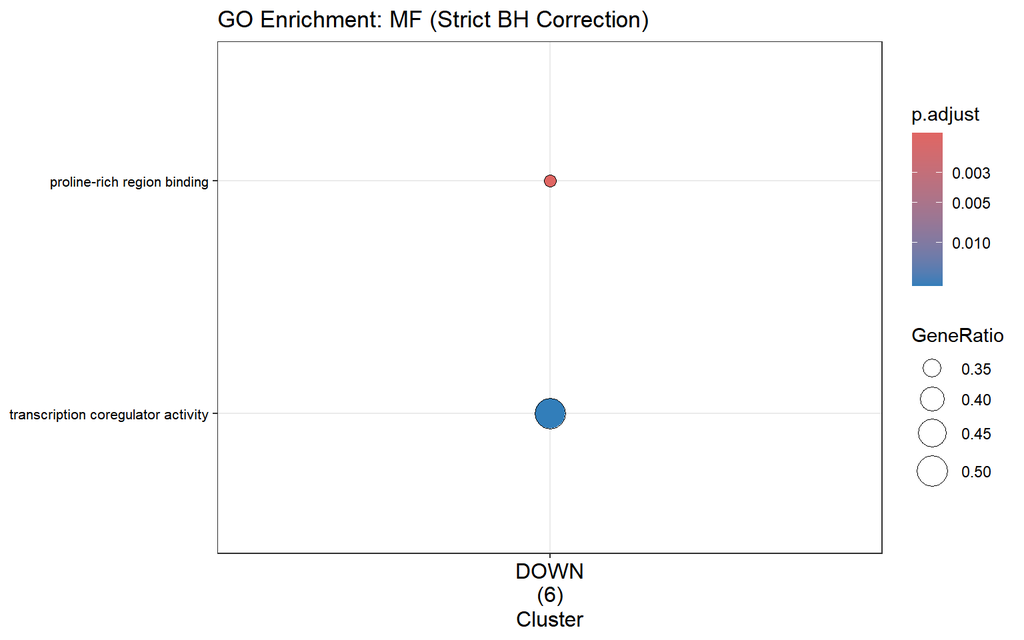

```r
#Molecular Function (MF), Bh
go_mf <- compareCluster(
  geneClusters = gene_list_strict,
  fun          = "enrichGO",
  OrgDb        = org.Mm.eg.db,
  keyType      = "SYMBOL",
  ont          = "MF",
  pvalueCutoff = 0.05,
  pAdjustMethod = "BH",
  universe     = gene_universe
)

if(!is.null(go_mf)) {
  print(
    dotplot(go_mf, showCategory = 10, title = "GO Enrichment: MF (Strict BH Correction)") +
      scale_y_discrete(labels = function(x) stringr::str_wrap(x, width = 45)) +
      theme(axis.text.y = element_text(size = 8))
  )
}
```

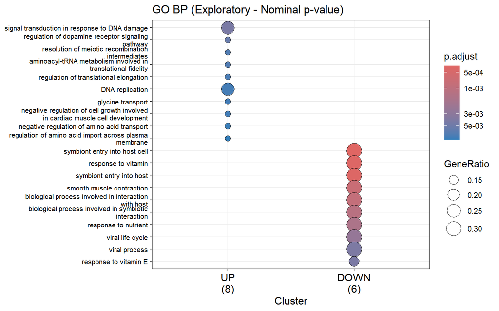

```r
#Phase 2: explorative approach (hypotesis)

#Biological Process (BP)
go_bp_none <- compareCluster(
  geneClusters = gene_list_strict,
  fun          = "enrichGO",
  OrgDb        = org.Mm.eg.db,
  keyType      = "SYMBOL",
  ont          = "BP",
  pvalueCutoff = 0.05,
  pAdjustMethod = "none",
  universe     = gene_universe
)

print(
  dotplot(go_bp_none, showCategory = 10, title = "GO BP (Exploratory - Nominal p-value)") +
    scale_y_discrete(labels = function(x) stringr::str_wrap(x, width = 45)) +
    theme(axis.text.y = element_text(size = 8))
)
```

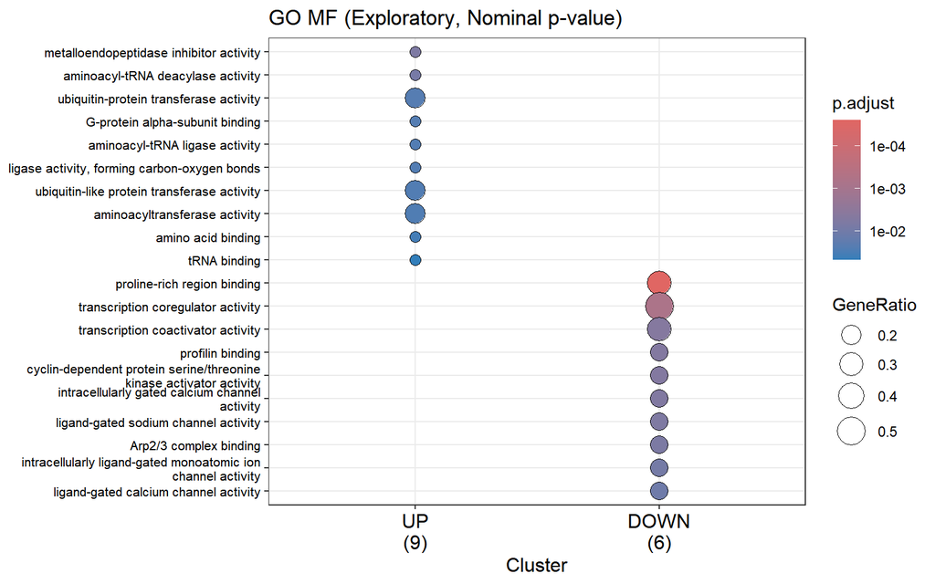

```r
#Molecular Function (MF)
go_mf_none <- compareCluster(
  geneClusters = gene_list_strict,
  fun          = "enrichGO",
  OrgDb        = org.Mm.eg.db,
  keyType      = "SYMBOL",
  ont          = "MF",
  pvalueCutoff = 0.05,
  pAdjustMethod = "none",
  universe     = gene_universe
)

print(
  dotplot(go_mf_none, showCategory = 10, title = "GO MF (Exploratory, Nominal p-value)") +
    scale_y_discrete(labels = function(x) stringr::str_wrap(x, width = 45)) +
    theme(axis.text.y = element_text(size = 8))
)
```

## Pathway Enrichment Analysis with Reactome

To complement the GO analysis, we perform a Pathway Enrichment Analysis using the Reactome database. Since Reactome requires Entrez Gene IDs, we first map our Ensembl identifiers, split them into Up and Down-regulated genes, and run the enrichment pipeline.

Standard Over-Representation Analysis (ORA) using the Reactome database with strict Benjamini-Hochberg correction ($p.adjust < 0.05$) yielded no significantly enriched pathways. Diagnostic inspection of the raw enrichment output revealed that this is a direct consequence of low statistical power driven by two factors:

- Database mapping attrition: out of the highly restricted core list of significant DEGs, only a minimal fraction (4 UP-regulated and 4 DOWN-regulated genes) successfully mapped to annotated Reactome pathways.
- FDR penalty on small inputs: due to the extremely small input size, the test lacked the required statistical power. While several pathways showed promising nominal p-values ($p < 0.01$), the rigorous multiple-testing correction inherently penalized these scores, pushing the lowest adjusted p-values just above the strict alpha threshold (lowest observed $FDR \approx 0.06$).

These mathematical limitations of threshold-based ORA on heavily filtered datasets perfectly justify the necessity of employing a threshold-free approach, such as Gene Set Enrichment Analysis (GSEA), to evaluate pathway-level dynamics across the entire continuous transcriptomic profile.

```r
# PATHWAY ENRICHMENT ANALYSIS WITH REACTOME: strictly requiring ENTREZ IDs

#Entrez IDs for the 19 significant core DEGs (padj < 0.05)
up_entrez_strict <- res_df$entrez[res_df$log2FoldChange > 0 & res_df$padj < 0.05 & !is.na(res_df$padj)]
down_entrez_strict <- res_df$entrez[res_df$log2FoldChange < 0 & res_df$padj < 0.05 & !is.na(res_df$padj)]

#Strict list for comparative analysis
gene_list_reactome_strict <- list(
  UP = na.omit(up_entrez_strict),
  DOWN = na.omit(down_entrez_strict)
)

#Performing the comparative pathway enrichment analysis with Reactome
reactome_strict <- compareCluster(
  geneClusters  = gene_list_reactome_strict,
  fun           = "enrichPathway",
  organism      = "mouse",
  pvalueCutoff  = 0.05,
  pAdjustMethod = "BH",
  universe      = entrez_universe
)

if (!is.null(reactome_strict) && nrow(as.data.frame(reactome_strict)) > 0) {
  print(
    dotplot(reactome_strict, showCategory = 10, title = "Reactome Pathway Enrichment (Strict BH)") +
      scale_y_discrete(labels = function(x) stringr::str_wrap(x, width = 45)) +
      theme(axis.text.y = element_text(size = 8))
  )
} else {
  cat("No Reactome pathways reached statistical significance under strict BH correction.\n")
}
```

```
## No Reactome pathways reached statistical significance under strict BH correction.
```

### Checking lost significant genes when mapping

```r
length(up_entrez_strict); length(na.omit(up_entrez_strict))
```

```
## [1] 12
```

```
## [1] 11
```

```r
length(down_entrez_strict); length(na.omit(down_entrez_strict))
```

```
## [1] 7
```

```
## [1] 6
```

```r
length(entrez_universe); length(na.omit(entrez_universe))
```

```
## [1] 17920
```

```
## [1] 15902
```

```r
sum(is.na(res_df$entrez[res_df$log2FoldChange > 0 & res_df$padj < 0.05 & !is.na(res_df$padj)]))
```

```
## [1] 1
```

```r
sum(is.na(res_df$entrez[res_df$log2FoldChange < 0 & res_df$padj < 0.05 & !is.na(res_df$padj)]))
```

```
## [1] 1
```

```r
reactome_up_raw <- enrichPathway(gene = na.omit(up_entrez_strict),
                                 organism = "mouse",
                                 universe = entrez_universe,
                                 pvalueCutoff = 1,
                                 pAdjustMethod = "BH")

if (!is.null(reactome_up_raw)) { head(as.data.frame(reactome_up_raw)) }
```

```
##                          ID
## R-MMU-73894     R-MMU-73894
## R-MMU-110314   R-MMU-110314
## R-MMU-6783310 R-MMU-6783310
## R-MMU-9864848 R-MMU-9864848
## R-MMU-606279   R-MMU-606279
## R-MMU-774815   R-MMU-774815
##                                                                    Description
## R-MMU-73894                                                         DNA Repair
## R-MMU-110314  Recognition of DNA damage by PCNA-containing replication complex
## R-MMU-6783310                                           Fanconi Anemia Pathway
## R-MMU-9864848                                              Complex IV assembly
## R-MMU-606279  Deposition of new CENPA-containing nucleosomes at the centromere
## R-MMU-774815                                               Nucleosome assembly
##               GeneRatio  BgRatio  RichFactor FoldEnrichment   zScore
## R-MMU-73894         2/4 273/7302 0.007326007       13.37363 4.878101
## R-MMU-110314        1/4  30/7302 0.033333333       60.85000 7.689836
## R-MMU-6783310       1/4  35/7302 0.028571429       52.15714 7.102021
## R-MMU-9864848       1/4  38/7302 0.026315789       48.03947 6.805900
## R-MMU-606279        1/4  42/7302 0.023809524       43.46429 6.460995
## R-MMU-774815        1/4  42/7302 0.023809524       43.46429 6.460995
##                    pvalue  p.adjust     qvalue      geneID Count
## R-MMU-73894   0.007949236 0.1224929 0.08205268 76843/69928     2
## R-MMU-110314  0.016336190 0.1224929 0.08205268       76843     1
## R-MMU-6783310 0.019039304 0.1224929 0.08205268       69928     1
## R-MMU-9864848 0.020658496 0.1224929 0.08205268       66272     1
## R-MMU-606279  0.022814299 0.1224929 0.08205268       69928     1
## R-MMU-774815  0.022814299 0.1224929 0.08205268       69928     1
```

```r
reactome_down_raw <- enrichPathway(gene = na.omit(down_entrez_strict),
                                   organism = "mouse",
                                   universe = entrez_universe,
                                   pvalueCutoff = 1,
                                   pAdjustMethod = "BH")

if (!is.null(reactome_down_raw)) { head(as.data.frame(reactome_down_raw)) }
```

```
##                        ID                                   Description
## R-MMU-264642 R-MMU-264642  Acetylcholine Neurotransmitter Release Cycle
## R-MMU-181430 R-MMU-181430 Norepinephrine Neurotransmitter Release Cycle
## R-MMU-181429 R-MMU-181429      Serotonin Neurotransmitter Release Cycle
## R-MMU-388844 R-MMU-388844   Receptor-type tyrosine-protein phosphatases
## R-MMU-210500 R-MMU-210500      Glutamate Neurotransmitter Release Cycle
## R-MMU-212676 R-MMU-212676       Dopamine Neurotransmitter Release Cycle
##              GeneRatio BgRatio RichFactor FoldEnrichment    zScore      pvalue
## R-MMU-264642       1/4 15/7302 0.06666667      121.70000 10.954631 0.008193320
## R-MMU-181430       1/4 16/7302 0.06250000      114.09375 10.601645 0.008737746
## R-MMU-181429       1/4 18/7302 0.05555556      101.41667  9.985650 0.009825924
## R-MMU-388844       1/4 19/7302 0.05263158       96.07895  9.714607 0.010369677
## R-MMU-210500       1/4 23/7302 0.04347826       79.36957  8.812411 0.012542449
## R-MMU-212676       1/4 23/7302 0.04347826       79.36957  8.812411 0.012542449
##              p.adjust     qvalue geneID Count
## R-MMU-264642  0.06181 0.02397064 233977     1
## R-MMU-181430  0.06181 0.02397064 233977     1
## R-MMU-181429  0.06181 0.02397064 233977     1
## R-MMU-388844  0.06181 0.02397064 233977     1
## R-MMU-210500  0.06181 0.02397064 233977     1
## R-MMU-212676  0.06181 0.02397064 233977     1
```

## REACTOME Explorative

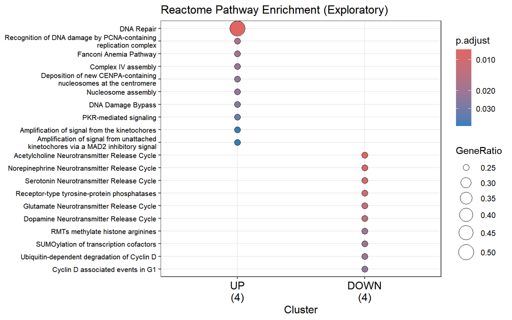

```r
reactome_explorative <- compareCluster(
  geneClusters  = gene_list_reactome_strict,
  fun           = "enrichPathway",
  organism      = "mouse",
  pvalueCutoff  = 0.05,
  pAdjustMethod = "none",
  universe      = entrez_universe
)

if (!is.null(reactome_explorative) && nrow(as.data.frame(reactome_explorative)) > 0) {
  print(
    dotplot(reactome_explorative, showCategory = 10,
            title = "Reactome Pathway Enrichment (Exploratory)") +
      scale_y_discrete(labels = function(x) stringr::str_wrap(x, width = 45)) +
      theme(axis.text.y = element_text(size = 8))
  )
} else {
  cat("No Reactome pathway with nominal p-value\n")
}
```

## Gene Set Enrichment Analysis (GSEA) with Hallmark gene sets

We used a threshold-free Gene Set Enrichment Analysis (GSEA) with the MSigDB Hallmark gene sets. Unlike standard Over-Representation Analysis (ORA), GSEA doesn’t use a strict p-value cutoff for the input list. Instead, it looks at the entire transcriptomic profile, ranking all genes based on their DESeq2 Wald statistic to keep track of both the direction and size of expression changes.

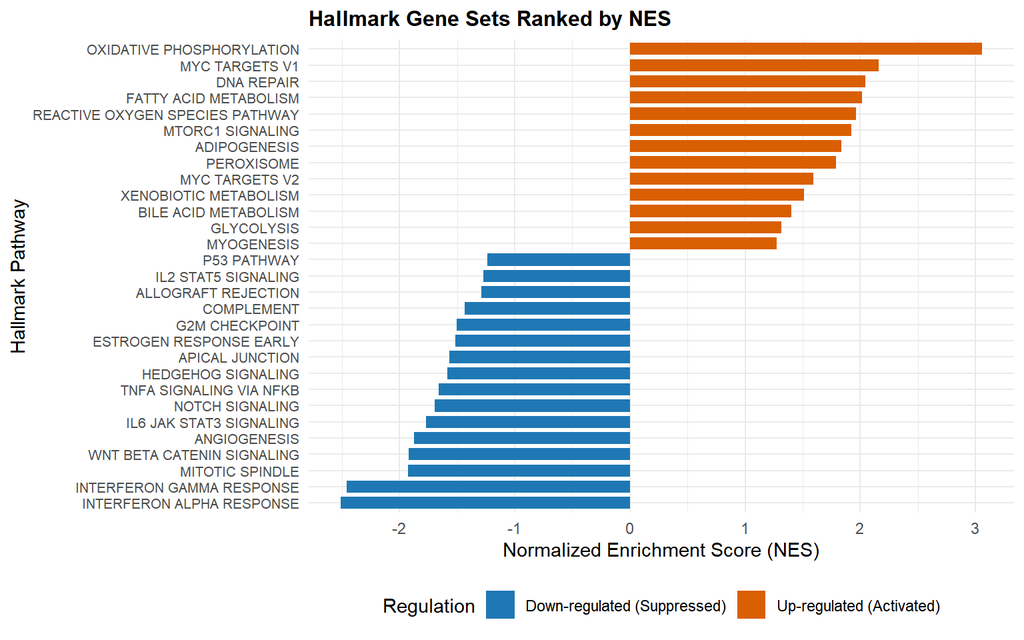

```r
#Gene Sets Hallmark download with Ensembl

#Hallmark GSEA
h_gene_sets <- msigdbr(species = "mouse", category = "H")
msigdbr_t2g <- as.data.frame(dplyr::distinct(h_gene_sets, gs_name, ensembl_gene))

res_gsea_df <- as.data.frame(res_clean)
res_gsea_df <- res_gsea_df[!is.na(res_gsea_df$stat), ]
rank <- res_gsea_df$stat
names(rank) <- rownames(res_gsea_df)
rank <- sort(rank, decreasing = TRUE)

gsea_res <- GSEA(
  geneList      = rank,
  TERM2GENE     = msigdbr_t2g,
  pvalueCutoff  = 0.1,
  pAdjustMethod = "BH",
  verbose       = FALSE
)

gsea_res_df <- as.data.frame(gsea_res)
gsea_res_df$Description <- gsub("HALLMARK_", "", gsea_res_df$Description)
gsea_res_df$Description <- gsub("_", " ", gsea_res_df$Description)
gsea_res_df$Regulation <- ifelse(gsea_res_df$NES > 0, "Up-regulated (Activated)", "Down-regulated (Suppressed)")
gsea_res_df <- gsea_res_df[order(gsea_res_df$NES, decreasing = TRUE), ]

# Bar plot NES
ggplot(gsea_res_df, aes(x = reorder(Description, NES), y = NES, fill = Regulation)) +
  geom_bar(stat = "identity", width = 0.75) +
  coord_flip() +
  scale_fill_manual(values = c("Up-regulated (Activated)" = "#d95f02", "Down-regulated (Suppressed)" = "#1f78b4")) +
  labs(title = "Hallmark Gene Sets Ranked by NES", x = "Hallmark Pathway", y = "Normalized Enrichment Score (NES)") +
  theme_minimal() +
  theme(axis.text.y = element_text(size = 8), plot.title = element_text(face = "bold", size = 12), legend.position = "bottom")
```

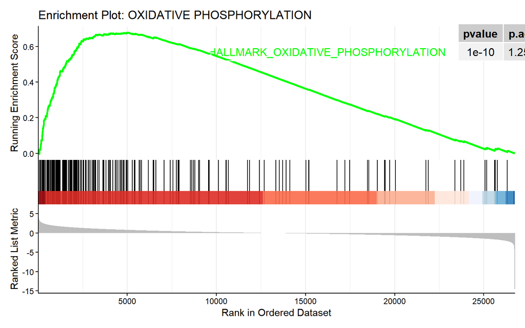

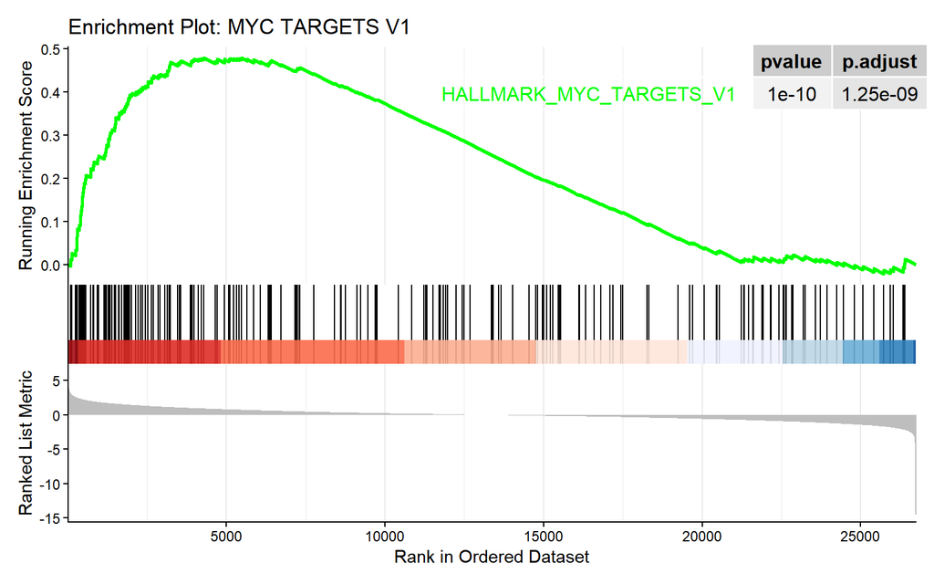

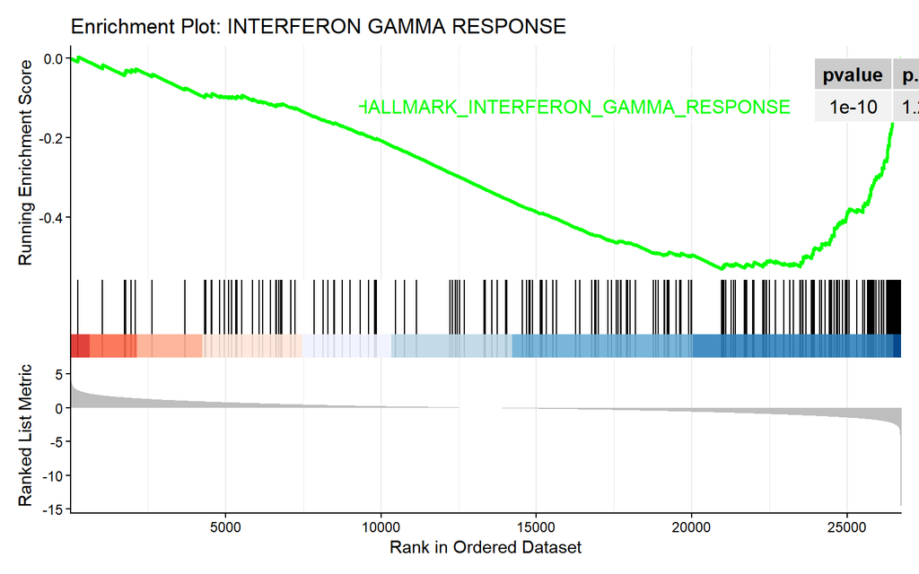

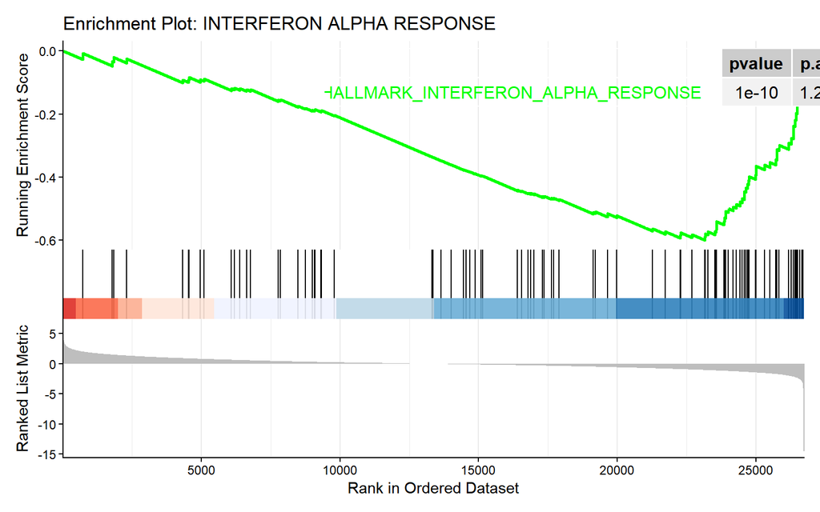

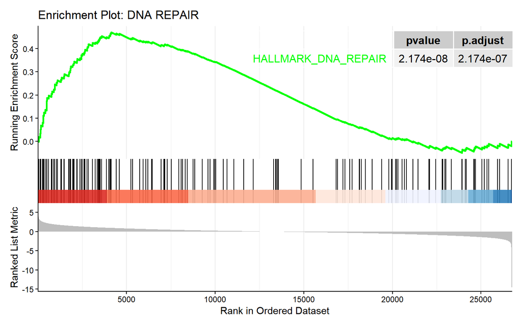

```r
#Enrichment plots, top 5
gsea_res_ordered <- gsea_res_df[order(gsea_res_df$pvalue), ]
top5_plots <- head(gsea_res_ordered$ID, 5)

for (pathway_id in top5_plots) {
  clean_title <- gsub("_", " ", gsub("HALLMARK_", "", pathway_id))
  print(gseaplot2(gsea_res, geneSetID = pathway_id,
                   title = paste("Enrichment Plot:", clean_title),
                   pvalue_table = TRUE))
}
```

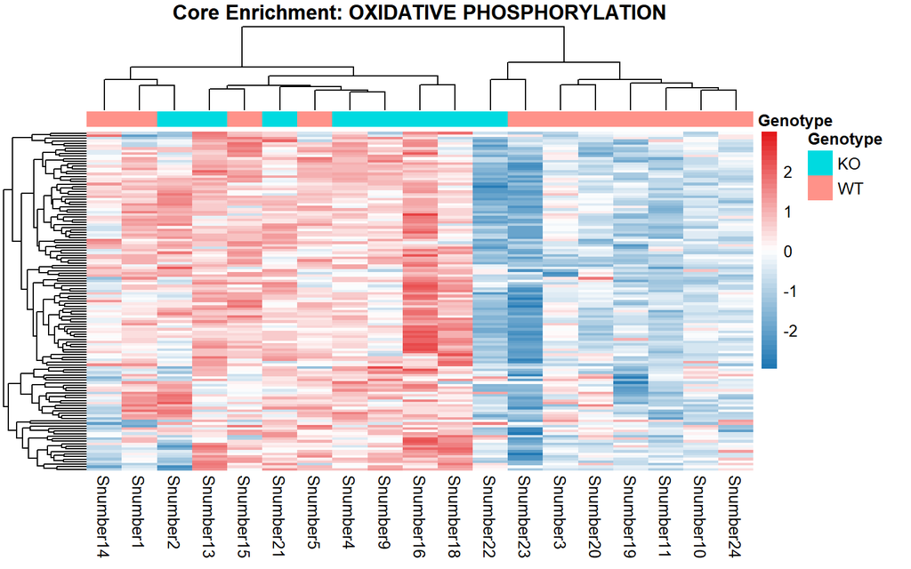

```r
#Heatmap
top_pathway_name <- gsea_res_ordered$Description[1]
core_ensembl <- unlist(strsplit(gsea_res_ordered$core_enrichment[1], "/"))

counts_matrix <- assay(vsd_clean)
heatmap_mat <- counts_matrix[rownames(counts_matrix) %in% core_ensembl, , drop = FALSE]

gene_symbols <- mapIds(org.Mm.eg.db, keys = rownames(heatmap_mat),
                        column = "SYMBOL", keytype = "ENSEMBL", multiVals = "first")
gene_symbols[is.na(gene_symbols)] <- rownames(heatmap_mat)[is.na(gene_symbols)]
rownames(heatmap_mat) <- make.unique(gene_symbols)

annotation_col <- data.frame(
  Genotype = colData(dds_clean)[colnames(heatmap_mat), "Genotype"]
)
rownames(annotation_col) <- colnames(heatmap_mat)

pheatmap(
  heatmap_mat,
  scale = "row",
  clustering_distance_rows = "euclidean",
  clustering_distance_cols = "euclidean",
  clustering_method = "complete",
  show_colnames = TRUE,
  show_rownames = FALSE,
  fontsize_row = 6,
  annotation_col = annotation_col,
  main = paste("Core Enrichment:", top_pathway_name),
  color = colorRampPalette(c("#1f78b4", "white", "#e31a1c"))(50)
)
```

## Questions

1. How many genes are differentially expressed at the thresholds of padj < 0.05? And padj < 0.1?

```r
res_clean_df <- as.data.frame(res_clean)

#Significant genes with padj < 0.05 e padj < 0.1
genes_padj_005 <- sum(res_clean_df$padj < 0.05, na.rm = TRUE)
genes_padj_01  <- sum(res_clean_df$padj < 0.10, na.rm = TRUE)

# Stampa dei risultati a schermo
cat("Significant genes (padj < 0.05):", genes_padj_005, "\n")
```

```
## Significant genes (padj < 0.05): 19
```

```r
cat("Significant genes (padj < 0.10):", genes_padj_01, "\n")
```

```
## Significant genes (padj < 0.10): 28
```

2. How many genes at the thresholds of padj < 0.05 are upregulated ( > 0) or downregulated?

```r
#Counting UP e DOWN genes with padj < 0.05
genes_up_005   <- sum(res_clean_df$padj < 0.05 & res_clean_df$log2FoldChange > 0, na.rm = TRUE)
genes_down_005 <- sum(res_clean_df$padj < 0.05 & res_clean_df$log2FoldChange < 0, na.rm = TRUE)

cat("Upregulated (log2FC > 0):", genes_up_005, "\n")
```

```
## Upregulated (log2FC > 0): 12
```

```r
cat("Downregulated (log2FC < 0):", genes_down_005, "\n")
```

```
## Downregulated (log2FC < 0): 7
```

3. Choice one of the GO enrichment results and report how many categories are significant (p.adjust < 0.05). Hint: first convert the object with GO results with as.data.frame function.

```r
go_df <- as.data.frame(go_bp)

num_categorie <- sum(go_df$p.adjust < 0.05, na.rm = TRUE)

cat("Significative categories:", num_categorie, "\n")
```

```
## Significative categories: 3
```

4. How many genes are present in the most enriched category of the GO BP enrichment result?

```r
geni_top <- go_df$Count[1]
nome_top <- go_df$Description[1]

cat("Category:", nome_top, "| Number of genes:", geni_top, "\n")
```

```
## Category: symbiont entry into host cell | Number of genes: 2
```

## DEGs Result Table

```r
#Csv format for the table
write.csv(as.data.frame(res_clean),
          file = "All_Genes_DE_Results.csv",
          row.names = TRUE)

# 19 Significant genes (DEGs with padj < 0.05)
degs_signif <- res_clean[which(res_clean$padj < 0.05), ]

# 19 Significant Genes Table (TXT)
write.table(as.data.frame(degs_signif),
            file = "Significant_DEGs_Results.txt",
            sep = "\t",
            row.names = TRUE,
            col.names = NA)
```